```python
import pandas as pd
import numpy as np
import matplotlib as mpl
import matplotlib.pyplot as plt
import seaborn as sns
```

```python
%matplotlib inline
#plt.style.use('ggplot')
plt.style.use('seaborn-darkgrid')
#sns.set_context("paper", font_scale=4.0)
sns.set_context("paper", font_scale=2.0)
#sns.set_palette("cubehelix", 8)
sns.set_palette("Paired")
# http://www.r-graph-gallery.com/38-rcolorbrewers-palettes/
```

# Differential Expression of RBPs between Male and Females Tissues

```python
rbp = pd.read_table('/projects/kesara/collaborators/Peter/AS-SD/results/deseq/DE_Sig.RBP.tsv')
rbp = rbp.set_index('Gene')
rbp = rbp.iloc[:,0:-1]
#df.tail()
rbp.head()
```

| Gene | Adipose - Subcutaneous | Adipose - Visceral (Omentum) | Adrenal Gland | Artery - Aorta | Artery - Coronary | Artery - Tibial | Bladder | Brain - Amygdala | Brain - Anterior cingulate cortex (BA24) | Brain - Caudate (basal ganglia) | ... | Nerve - Tibial | Pancreas | Pituitary | Skin - Not Sun Exposed (Suprapubic) | Skin - Sun Exposed (Lower leg) | Small Intestine - Terminal Ileum | Spleen | Stomach | Thyroid | Whole Blood |
| --- | --- | --- | --- | --- | --- | --- | --- | --- | --- | --- | --- | --- | --- | --- | --- | --- | --- | --- | --- | --- | --- |
| ZRSR2 | 0.337531 | 0.318124 | 0.489181 | 0.520267 | 0.390085 | 0.527744 | NaN | NaN | NaN | NaN | ... | 0.412835 | 0.533726 | 0.454299 | 0.551365 | 0.541408 | 0.568604 | 0.368137 | 0.362942 | 0.499883 | 0.303169 |
| CELF4 | NaN | NaN | NaN | NaN | NaN | NaN | NaN | NaN | NaN | NaN | ... | NaN | NaN | NaN | 0.269021 | 0.246390 | NaN | NaN | NaN | NaN | NaN |
| SF3B2 | NaN | NaN | NaN | NaN | NaN | NaN | NaN | NaN | NaN | NaN | ... | NaN | NaN | NaN | NaN | NaN | NaN | NaN | NaN | -0.067464 | NaN |
| HNRNPM | NaN | NaN | NaN | NaN | NaN | NaN | NaN | NaN | NaN | NaN | ... | NaN | NaN | NaN | NaN | NaN | NaN | NaN | NaN | -0.111592 | -0.150523 |
| EWSR1 | NaN | NaN | NaN | NaN | NaN | NaN | NaN | NaN | NaN | NaN | ... | NaN | NaN | NaN | NaN | NaN | NaN | NaN | NaN | NaN | NaN |

5 rows × 45 columns

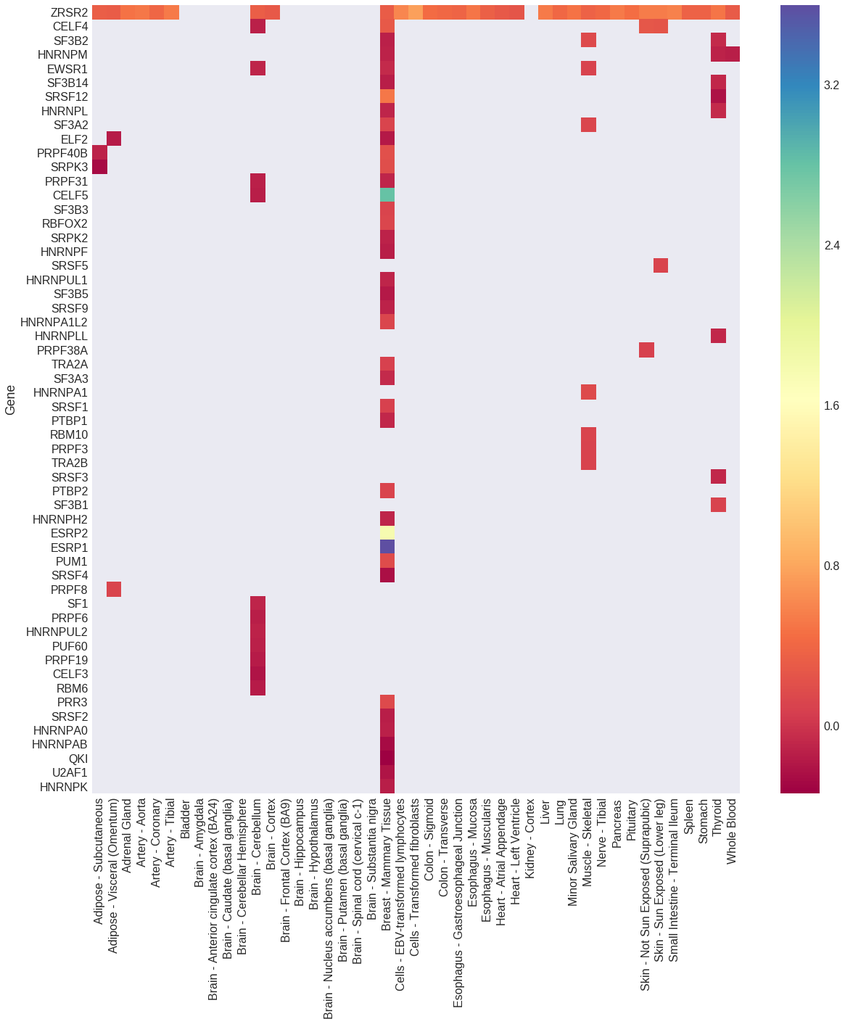

```python
plt.subplots(figsize=(20,20))
#sns.heatmap(rbp, cmap="YlGnBu")
#sns.heatmap(rbp, cmap="PiYG")
sns.heatmap(rbp, cmap="Spectral")
```

# Differential Expression of Genes between Male and Females Tissues

- DESeq Results (adj <=0.05)
- Heatmap for top genes which are found to be differentially expressed (adj <=0.05) in across many tissues.
- Scale shows log Fold Change as determined by DESeq

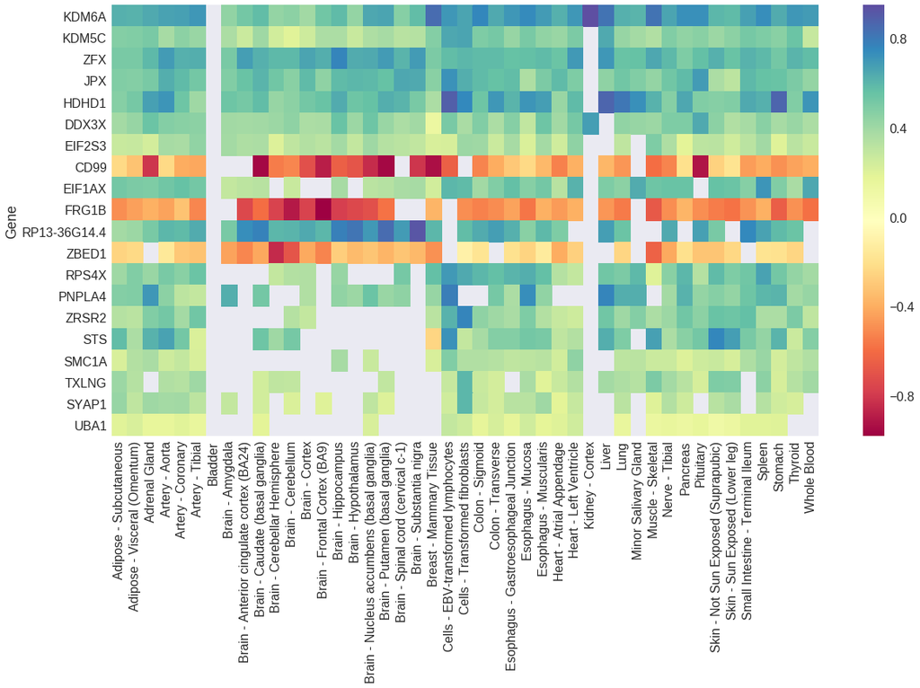

```python
df = pd.read_table('/projects/kesara/collaborators/Peter/AS-SD/results/deseq/DE_Sig.tsv')
df = df.set_index('Gene')
df = df.iloc[:,0:-1]
#df.head(10)
plt.figure(figsize=(20,10))
#sns.heatmap(df.head(20), cmap="YlGnBu")
sns.heatmap(df.head(20), cmap="Spectral")
```

# Genes including RBPs with frequent alterations in their expression levels (TPM) in male vs female tissues

# ZRSR2

- chrX
- Zinc Finger CCCH-Type, RNA Binding Motif And Serine/Arginine Rich 2. Pre-mRNA-binding protein required for splicing of both U2- and U12-type introns. Selectively interacts with the 3-splice site of U2- and U12-type pre-mRNAs and promotes different steps in U2 and U12 intron splicing. Recruited to U12 pre-mRNAs in an ATP-dependent manner and is required for assembly of the prespliceosome, a precursor to other spliceosomal complexes. For U2-type introns, it is selectively and specifically required for the second step of splicing.

```
Text(0.5,1,u'ZRSR2')
```

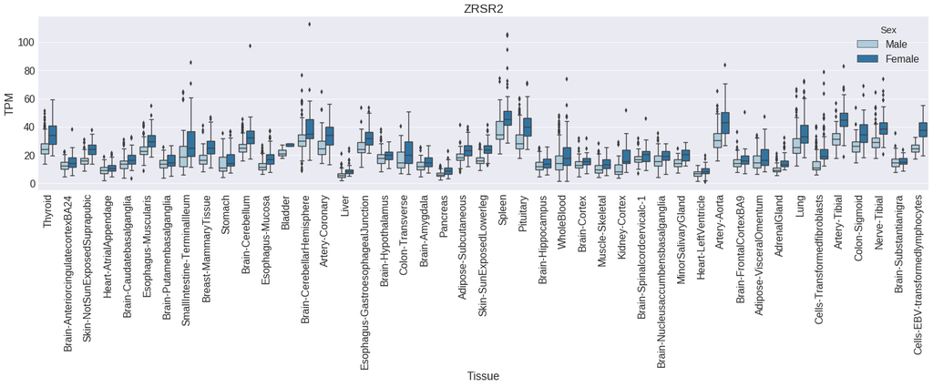

```python
tpm = pd.read_csv('/projects/kesara/collaborators/Peter/AS-SD/results/TPM/ZRSR2_tpm.csv')
plt.figure(figsize=(25,5))
ax = sns.boxplot(x="Tissue", y="TPM", hue="Sex", data=tpm)
plt.xticks(rotation=90)
#ax.set_yscale('log')
ax.set_title('ZRSR2')
```

# ZFX

- chrX
- (Zinc Finger Protein, X-Linked) is a Protein Coding gene. This gene on the X chromosome is structurally similar to a related gene on the Y chromosome. It encodes a member of the krueppel C2H2-type zinc-finger protein family. The full-length protein contains an acidic transcriptional activation domain (AD), a nuclear localization sequence (NLS) and a DNA binding domain (DBD) consisting of 13 C2H2-type zinc fingers. Studies in mouse embryonic and adult hematopoietic stem cells showed that this gene was required as a transcriptional regulator for self-renewal of both stem cell types, but it was dispensable for growth and differentiation of their progeny. Multiple alternatively spliced transcript variants encoding different isoforms have been identified, but the full-length nature of some variants has not been determined. [provided by RefSeq, May 2010]

```
Text(0.5,1,u'ZFX')
```

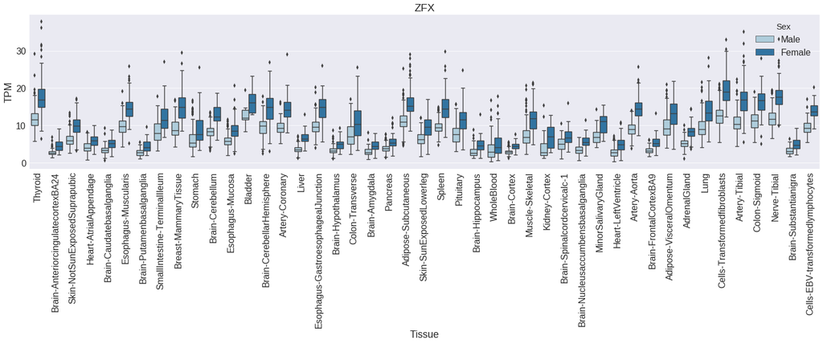

```python
tpm = pd.read_csv('/projects/kesara/collaborators/Peter/AS-SD/results/TPM/ZFX_tpm.csv')
plt.figure(figsize=(25,5))
ax = sns.boxplot(x="Tissue", y="TPM", hue="Sex", data=tpm)
plt.xticks(rotation=90)
#ax.set_yscale('log')
ax.set_title('ZFX')
```

# KDM6A

This gene is located on the X chromosome and is the corresponding locus to a Y-linked gene which encodes a tetratricopeptide repeat (TPR) protein. The encoded protein of this gene contains a JmjC-domain and catalyzes the demethylation of tri/dimethylated histone H3. Multiple alternatively spliced transcript variants have been found for this gene. [provided by RefSeq, Apr 2014]

```
Text(0.5,1,u'KDM6A')
```

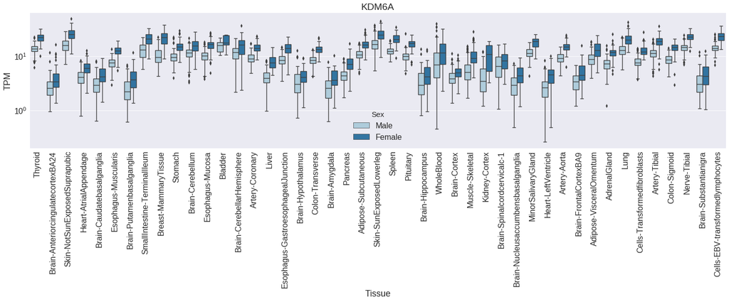

```python
tpm = pd.read_csv('/projects/kesara/collaborators/Peter/AS-SD/results/TPM/KDM6A_tpm.csv')
plt.figure(figsize=(25,5))
ax = sns.boxplot(x="Tissue", y="TPM", hue="Sex", data=tpm)
plt.xticks(rotation=90)
ax.set_yscale('log')
ax.set_title('KDM6A')
```

# RP13-36G14.4

Upregulatin of this gene in female in context of sex dimorphism https://www.ncbi.nlm.nih.gov/pmc/articles/PMC5769539/

```
Text(0.5,1,u'RP13-36G14.4')
```

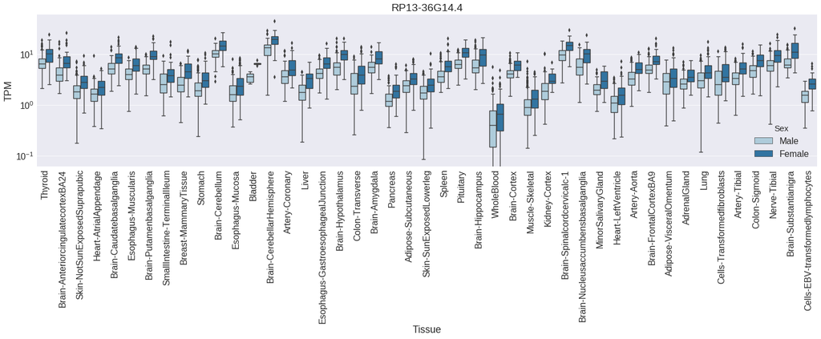

```python
tpm = pd.read_csv('/projects/kesara/collaborators/Peter/AS-SD/results/TPM/RP13-36G14.4_tpm.csv')
plt.figure(figsize=(25,5))
ax = sns.boxplot(x="Tissue", y="TPM", hue="Sex", data=tpm)
plt.xticks(rotation=90)
ax.set_yscale('log')
ax.set_title('RP13-36G14.4')
```

# Expression of intersting 10 RBPs in Male vs. Female Tissues (from Guy)

plotted are the TPM (log) of RBPs extracted from GTEx repository

```
Text(0.5,1,u'SNRNP70')
```

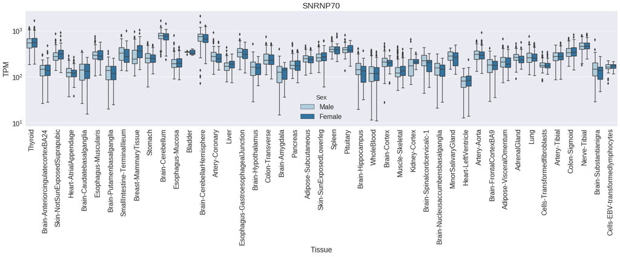

```python
tpm = pd.read_csv('/projects/kesara/collaborators/Peter/AS-SD/results/TPM/SNRNP70_tpm.csv')
plt.figure(figsize=(25,5))
ax = sns.boxplot(x="Tissue", y="TPM", hue="Sex", data=tpm)
plt.xticks(rotation=90)
ax.set_yscale('log')
ax.set_title('SNRNP70')
```

```
Text(0.5,1,u'HNRNPA1')
```

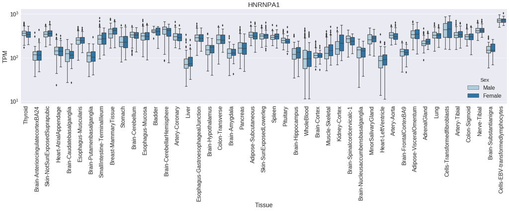

```python
tpm = pd.read_csv('/projects/kesara/collaborators/Peter/AS-SD/results/TPM/HNRNPA1_tpm.csv')
plt.figure(figsize=(25,5))
ax = sns.boxplot(x="Tissue", y="TPM", hue="Sex", data=tpm)
plt.xticks(rotation=90)
ax.set_yscale('log')
ax.set_title('HNRNPA1')
```

```
Text(0.5,1,u'YBX1')
```

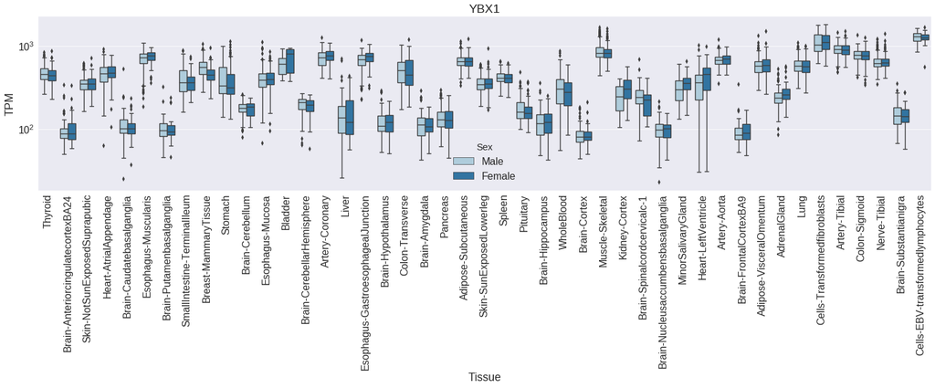

```python
tpm = pd.read_csv('/projects/kesara/collaborators/Peter/AS-SD/results/TPM/YBX1_tpm.csv')
plt.figure(figsize=(25,5))
ax = sns.boxplot(x="Tissue", y="TPM", hue="Sex", data=tpm)
plt.xticks(rotation=90)
ax.set_yscale('log')
ax.set_title('YBX1')
```

```
Text(0.5,1,u'FUS')
```

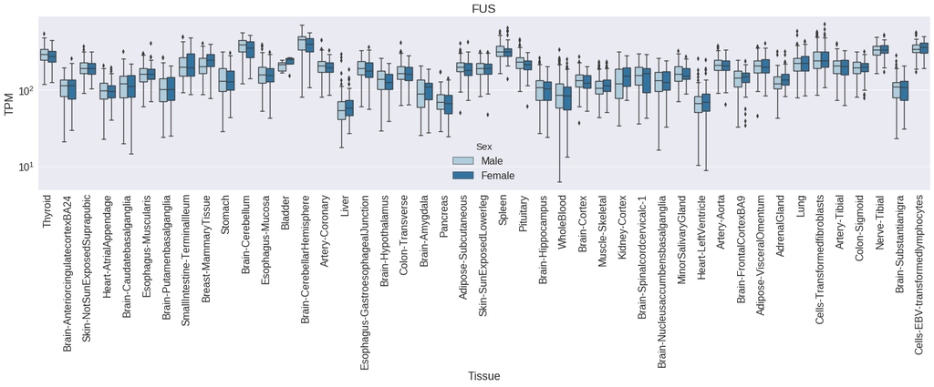

```python
tpm = pd.read_csv('/projects/kesara/collaborators/Peter/AS-SD/results/TPM/FUS_tpm.csv')
f,axes = plt.subplots(figsize=(25,5))
ax = sns.boxplot(x="Tissue", y="TPM", hue="Sex", data=tpm)
plt.xticks(rotation=90)
ax.set_yscale('log')
ax.set_title('FUS')
```

```
Text(0.5,1,u'HNRNPA2B1')
```

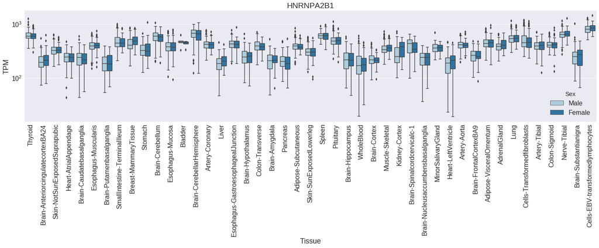

```python
tpm = pd.read_csv('/projects/kesara/collaborators/Peter/AS-SD/results/TPM/HNRNPA2B1_tpm.csv')
f,axes = plt.subplots(figsize=(25,5))
ax = sns.boxplot(x="Tissue", y="TPM", hue="Sex", data=tpm)
plt.xticks(rotation=90)
ax.set_yscale('log')
ax.set_title('HNRNPA2B1')
```

```
Text(0.5,1,u'SF1')
```

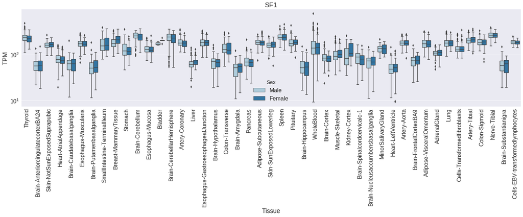

```python
tpm = pd.read_csv('/projects/kesara/collaborators/Peter/AS-SD/results/TPM/SF1_tpm.csv')
f,axes = plt.subplots(figsize=(25,5))
ax = sns.boxplot(x="Tissue", y="TPM", hue="Sex", data=tpm)
plt.xticks(rotation=90)
ax.set_yscale('log')
ax.set_title('SF1')
```

```
Text(0.5,1,u'HNRNPK')
```

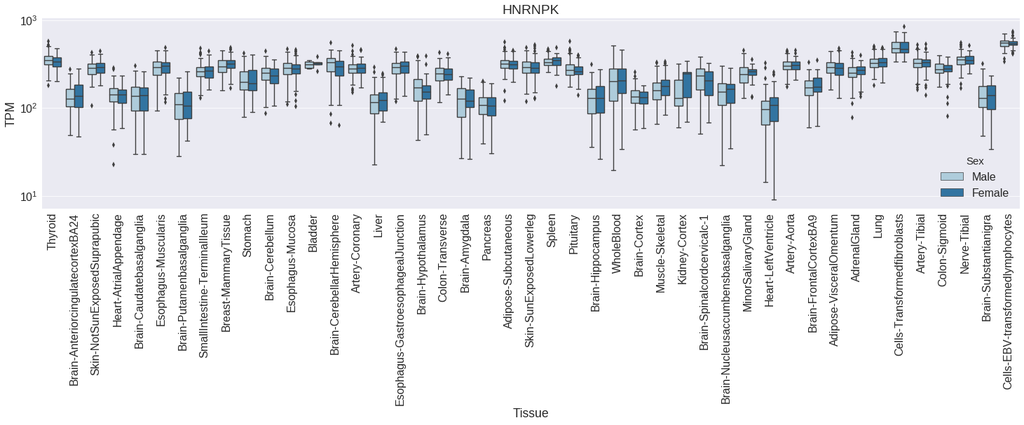

```python
tpm = pd.read_csv('/projects/kesara/collaborators/Peter/AS-SD/results/TPM/HNRNPK_tpm.csv')
f,axes = plt.subplots(figsize=(25,5))
ax = sns.boxplot(x="Tissue", y="TPM", hue="Sex", data=tpm)
plt.xticks(rotation=90)
ax.set_yscale('log')
ax.set_title('HNRNPK')
```

```
Text(0.5,1,u'PABPN1')
```

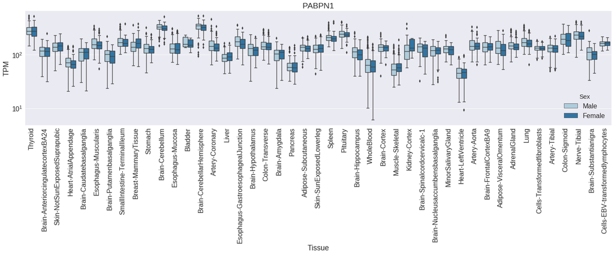

```python
tpm = pd.read_csv('/projects/kesara/collaborators/Peter/AS-SD/results/TPM/PABPN1_tpm.csv')
f,axes = plt.subplots(figsize=(25,5))
ax = sns.boxplot(x="Tissue", y="TPM", hue="Sex", data=tpm)
plt.xticks(rotation=90)
ax.set_yscale('log')
ax.set_title('PABPN1')
```

```
Text(0.5,1,u'HNRNPH1')
```

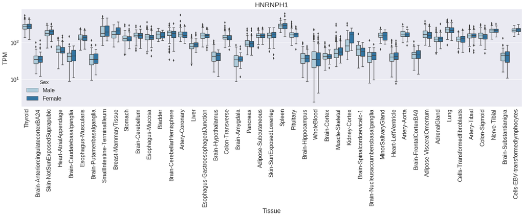

```python
tpm = pd.read_csv('/projects/kesara/collaborators/Peter/AS-SD/results/TPM/HNRNPH1_tpm.csv')
f,axes = plt.subplots(figsize=(25,5))
ax = sns.boxplot(x="Tissue", y="TPM", hue="Sex", data=tpm)
plt.xticks(rotation=90)
ax.set_yscale('log')
ax.set_title('HNRNPH1')
```

```
Text(0.5,1,u'HNRNPL')
```

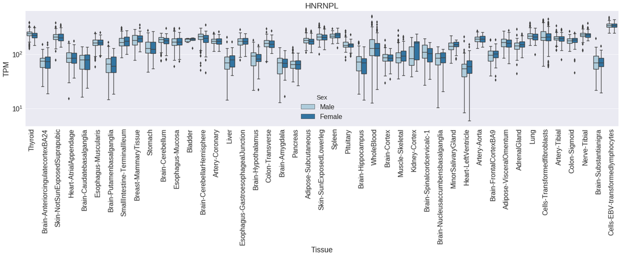

```python
tpm = pd.read_csv('/projects/kesara/collaborators/Peter/AS-SD/results/TPM/HNRNPL_tpm.csv')
f,axes = plt.subplots(figsize=(25,5))
ax = sns.boxplot(x="Tissue", y="TPM", hue="Sex", data=tpm)
plt.xticks(rotation=90)
ax.set_yscale('log')
ax.set_title('HNRNPL')
```

```
Text(0.5,1,u'XIST')
```

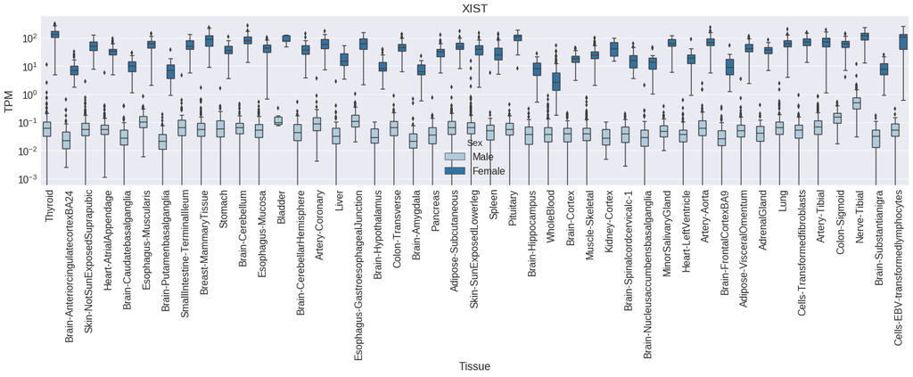

```python
tpm = pd.read_csv('/projects/kesara/collaborators/Peter/AS-SD/results/TPM/XIST_tpm.csv')
plt.figure(figsize=(25,5))
ax = sns.boxplot(x="Tissue", y="TPM", hue="Sex", data=tpm)
plt.xticks(rotation=90)
ax.set_yscale('log')
ax.set_title('XIST')
```